# Data Exploration of the performance of students in Mathematics and Science, based on the results of the PISA 2012 test

## by (Iraklis Kalamas)

Quoting from the Organisation for Economic Co-operation and Development web site (http://www.oecd.org/pisa/):

> "The Programme for International Student Assessment (PISA) is the OECD's Programme for International Student Assessment. PISA measures 15-year-olds’ ability to use their reading, mathematics and science knowledge and skills to meet real-life challenges. More specifically PISA 2012 is the programme’s 5th survey. It assessed the competencies of 15-year-olds in reading, mathematics and science (with a focus on mathematics) in 65 countries and economies. In 44 of those countries and economies about 85 000 students also took part in an optional assessment of creative problem solving; and in 18 countries and economies, students were assessed in financial literacy."

## Preliminary Wrangling

### For a detailed description of the Wrangling procces please refer to "Data_Cleaning_Proccess" notebook.

```python
#all needed packages imported and set plots to be embedded inline
import numpy as np
import pandas as pd
import matplotlib.pyplot as plt
import seaborn as sb

%matplotlib inline
```

```python
#reading the dataset into a dataframe using only the needed columns
df = pd.read_csv("data/pisa2012_final.csv")
```

##### Examining several aspects of the dataset

```python
df.info()
```

```
<class 'pandas.core.frame.DataFrame'>
RangeIndex: 347783 entries, 0 to 347782
Data columns (total 10 columns):
 #   Column                    Non-Null Count   Dtype
---  ------                    --------------   -----
 0   Country                   347783 non-null  object
 1   Student_Id                347783 non-null  int64
 2   Gender                    347783 non-null  object
 3   Study_Time_With_Parent    347783 non-null  int64
 4   Parent_Highest_Education  347783 non-null  object
 5   Math_Score                347783 non-null  float64
 6   Science_Score             347783 non-null  float64
 7   Parents_Present           347783 non-null  object
 8   Siblings_Present          347783 non-null  object
 9   Mean_Score                347783 non-null  float64
dtypes: float64(3), int64(2), object(5)
memory usage: 26.5+ MB
```

```python
df.head()
```

|  | Country | Student_Id | Gender | Study_Time_With_Parent | Parent_Highest_Education | Math_Score | Science_Score | Parents_Present | Siblings_Present | Mean_Score |
| --- | --- | --- | --- | --- | --- | --- | --- | --- | --- | --- |
| 0 | Albania | 1 | Female | 1 | ISCED 3A, ISCED 4 | 406.8469 | 341.7009 | Both_Parents | Yes | 374.27390 |
| 1 | Albania | 3 | Female | 2 | ISCED 5A, 6 | 533.2684 | 499.6643 | Both_Parents | No | 516.46635 |
| 2 | Albania | 4 | Female | 0 | ISCED 5A, 6 | 412.2215 | 438.6796 | Both_Parents | No | 425.45055 |
| 3 | Albania | 6 | Female | 1 | ISCED 3B, C | 396.3312 | 384.3156 | Both_Parents | No | 390.32340 |
| 4 | Albania | 7 | Female | 0 | ISCED 5A, 6 | 438.0823 | 508.1499 | Both_Parents | No | 473.11610 |

```python
df.describe()
```

|  | Student_Id | Study_Time_With_Parent | Math_Score | Science_Score | Mean_Score |
| --- | --- | --- | --- | --- | --- |
| count | 347783.000000 | 347783.000000 | 347783.000000 | 347783.000000 | 347783.000000 |
| mean | 6046.328512 | 1.127030 | 477.589703 | 482.959368 | 480.274536 |
| std | 6654.061246 | 1.836489 | 102.934052 | 100.633185 | 99.260504 |
| min | 1.000000 | 0.000000 | 19.792800 | 6.844500 | 13.318650 |
| 25% | 1803.000000 | 0.000000 | 403.341600 | 411.917200 | 408.963500 |
| 50% | 3721.000000 | 1.000000 | 474.536500 | 482.786300 | 478.664300 |
| 75% | 7244.000000 | 1.000000 | 549.314500 | 554.587800 | 550.742175 |
| max | 33806.000000 | 30.000000 | 962.229300 | 903.338300 | 895.624150 |

### Now I'm ready to answer the following questions

### What is the structure of your dataset?

> The final data set contains 10 features and 347783 observations. This is a part of the original data, sufficient for my analysis.

### What is/are the main feature(s) of interest in your dataset?

> My main interest is to find insights for the score of students in math and science in relation to their family structure.

### What features in the dataset do you think will help support your investigation into your feature(s) of interest?

> I'll need the scores of students in math and science and data from family structure such as the level of education of the parent(s), the presence or not of the parent(s) at home, if the presence of siblings affect the performance of students and the time that parent(s) spend with the student.

## Univariate Exploration

> In this section, investigate distributions of individual variables. If you see unusual points or outliers, take a deeper look to clean things up and prepare yourself to look at relationships between variables.

#### Let's start viewing usefull facts about our data

```python
# Gender column
df.Gender.value_counts()
```

```
Female    174889
Male      172894
Name: Gender, dtype: int64
```

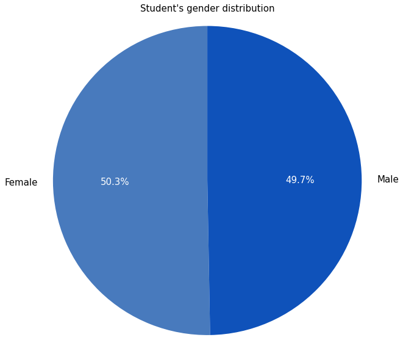

```python
fig, ax = plt.subplots(1, 1, figsize=(10, 10))
patches, texts, autotexts = ax.pie(df.Gender.value_counts(),
                                    colors = ['#487ABD','#0f52ba'],
                                    labels=['Female','Male'],
                                    autopct='%1.1f%%',
                                    startangle=90
                                   )
for text in texts:
    text.set_color('black')
    text.set_size(15)

for text in autotexts:
    text.set_color('white')
    text.set_size(15)

ax.axis('equal');
plt.title("Student's gender distribution", fontsize = 15)
plt.show();
```

- ##### The distribution of Female and Male students is almost the same (no bias exist)

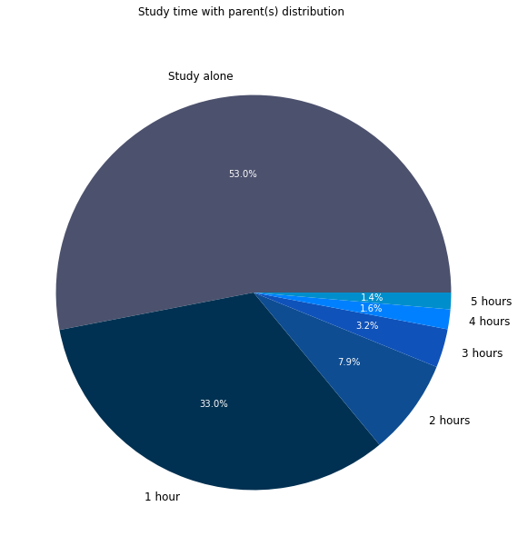

```python
# Study_Time_With_Parent column
fig, ax = plt.subplots(1, 1, figsize=(15, 10))

five = df[df['Study_Time_With_Parent'] < 6]['Study_Time_With_Parent'].value_counts()

patches, texts, autotexts = ax.pie(five,
                                    colors = ['#4c516d','#003152','#0e4d92','#0f52ba','#0080ff','#008ecc'],
                                    labels=['Study alone', '1 hour', '2 hours', '3 hours', '4 hours', '5 hours'],
                                    autopct='%1.1f%%',
                                    startangle=360
                                   )
for text in texts:
    text.set_color('black')
    text.set_size(12)
for text in autotexts:
    text.set_color('white')
    text.set_size(10)


plt.suptitle('Study time with parent(s) distribution', y=0.94)
plt.show();
```

- #### Students working more than 5 hours with their parent(s) is rare
- #### 53% of the students don't work with their parents
- #### 47% of the students work with their parents

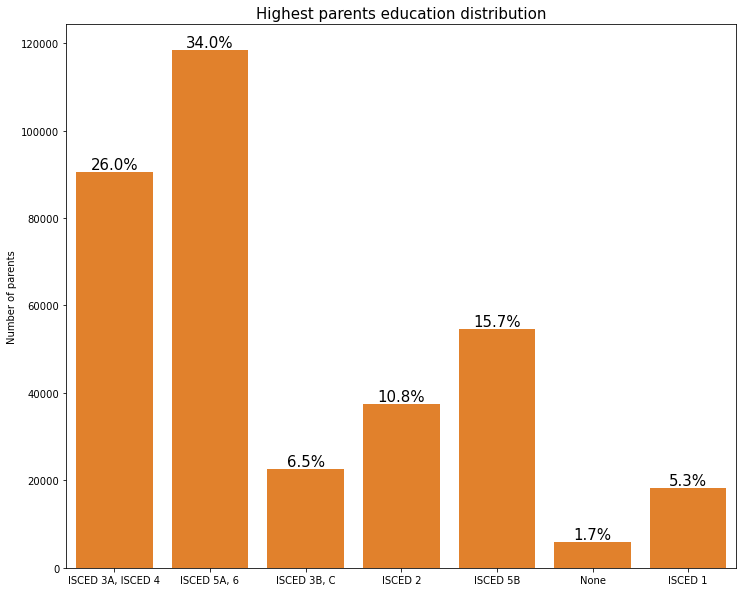

```python
# Parent_Highest_Education column
plt.figure(figsize=[12, 10]);
sb.countplot(x = 'Parent_Highest_Education', data = df, color = sb.color_palette()[1]);

points = df.shape[0]
education_counts = df.Parent_Highest_Education.value_counts()
locs, labels = plt.xticks()

for loc, label in zip(locs, labels):

    count = education_counts[label.get_text()]
    pct_string = '{:0.1f}%'.format(100*count/points)

    plt.text(loc, count, pct_string, ha = 'center', va='bottom', color = 'black', fontsize=15)

plt.ylabel('Number of parents')
plt.xlabel('')
plt.title('Highest parents education distribution', fontsize=15);
```

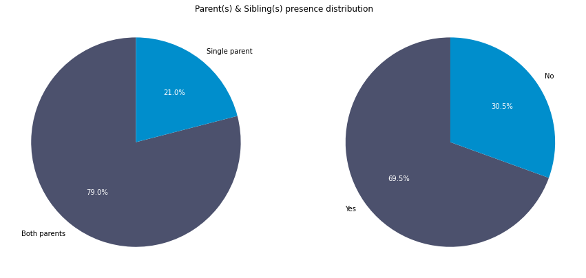

```python
# Parents presence at home
fig, (ax1, ax2) = plt.subplots(1, 2, figsize=(15, 7))
patches, texts, autotexts = ax1.pie(df.Parents_Present.value_counts(), colors = ['#4c516d','#008ecc'],
                                    labels=['Both parents','Single parent'],
                                    autopct='%1.1f%%',
                                    startangle=90
                                   )
for text in texts:
    text.set_color('black')

for text in autotexts:
    text.set_color('white')

patches, texts, autotexts = ax2.pie(df.Siblings_Present.value_counts(), colors = ['#4c516d','#008ecc'], labels=['Yes','No'],
                                    autopct='%1.1f%%',
                                    startangle=90
                                   )
for text in texts:
    text.set_color('black')

for text in autotexts:
    text.set_color('white')


plt.suptitle('Parent(s) & Sibling(s) presence distribution', y=0.9, ha='center')
plt.show();
```

- #### One out of five families its a single parent family
- #### 70% of students has sibling(s)

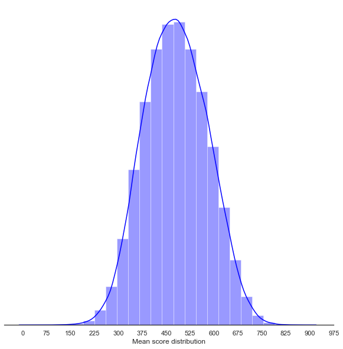

```python
# Mean_Score column
sb.set(style='white')
f, axes = plt.subplots(1, 1, figsize=(10, 10), sharex=True)

sb.despine(left=True)
sb.distplot(df.Mean_Score, bins=25, color = "blue")

x_ticks = np.arange(0, 1000, 75)
plt.xticks(x_ticks, x_ticks)
plt.setp(axes, yticks=[])
plt.xlabel('Mean score distribution');
```

```python
df.Mean_Score.quantile(0.05), df.Mean_Score.quantile(0.5), df.Mean_Score.quantile(0.95)
```

```
(320.980465, 478.6643, 645.0078749999999)
```

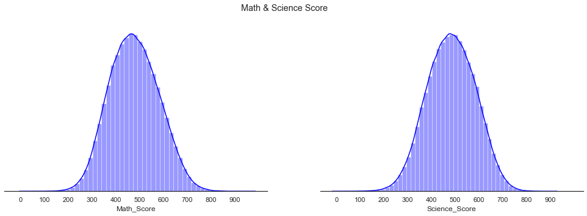

```python
sb.set(style='white')
f, axes = plt.subplots(1, 2, figsize=(17, 5), sharex=True)
sb.despine(left=True)

sb.distplot(df.Math_Score, ax=axes[0], bins=50, color = "blue")
sb.distplot(df.Science_Score, ax=axes[1], bins=50, color = "blue")

x_ticks = np.arange(0, 1000, 100)
plt.xticks(x_ticks);
plt.setp(axes, yticks=[]);
plt.suptitle('Math & Science Score')
plt.show();
```

```python
df.Math_Score.quantile(0.05), df.Math_Score.quantile(0.5), df.Math_Score.quantile(0.95)
```

```
(314.5428, 474.5365, 650.7322)
```

```python
df.Science_Score.quantile(0.05), df.Science_Score.quantile(0.5), df.Science_Score.quantile(0.95)
```

```
(318.6684, 482.7863, 646.7176)
```

- ##### The scores are normally distributed
- ##### Most of the students' scores are between 314 and 651 points
- ##### The mean of the individual course distributions is very close to 480 points which is also the mean of Mean_Score
- ##### The above facts shows that the evaluators of the tests did a balanced grading

## Bivariate Exploration

> In this section, investigate relationships between pairs of variables in your data. Make sure the variables that you cover here have been introduced in some fashion in the previous section (univariate exploration).

#### Gender and Scores

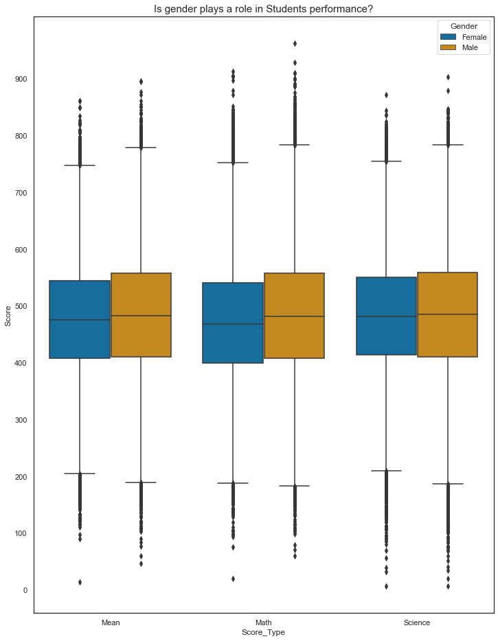

```python
df_gender_scores = pd.melt(df, id_vars=['Country', 'Student_Id', 'Gender', 'Study_Time_With_Parent',
                            'Parent_Highest_Education', 'Parents_Present', 'Siblings_Present'],
               value_vars=['Mean_Score','Math_Score','Science_Score'],
               var_name="Score_Type", value_name='Score')
df_gender_scores.Score_Type = df_gender_scores.Score_Type.replace('Mean_Score', 'Mean').replace('Math_Score','Math').replace('Science_Score','Science')

plt.figure(figsize=[12, 16])
sb.boxplot(x = df_gender_scores.Score_Type, y = df_gender_scores.Score, hue=df_gender_scores.Gender, palette = sb.color_palette('colorblind', 3))
plt.title('Is gender plays a role in Students performance?', fontsize=15)
y_ticks = np.arange(0, 1000, 100)
plt.yticks(y_ticks, y_ticks);
```

- #### In math male students have higher scores than female ones
- #### In science male students also have higher scores than female ones, but marginally
- #### The mean score favorites male studens

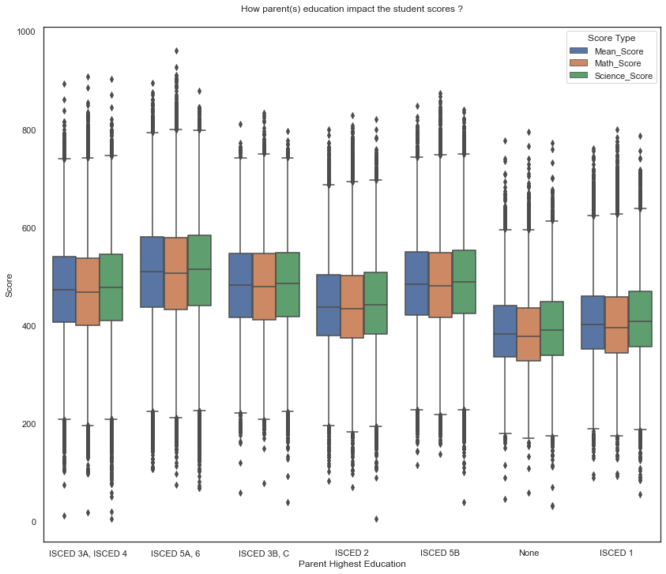

```python
score_df = pd.melt(df, id_vars=['Parent_Highest_Education'],
               value_vars=['Mean_Score', 'Math_Score', 'Science_Score'],
               var_name="Score_Type", value_name='Score')

fig, ax = plt.subplots(1, 1, figsize=(14, 12))
ax = sb.boxplot(data = score_df, x = 'Parent_Highest_Education', y='Score', hue=score_df.Score_Type.tolist());

ax.set(xlabel='Parent Highest Education', ylabel='Score')
plt.title("How parent(s) education impact the student scores ?", y=1.02)
ax.legend(title='Score Type')

plt.show();
```

#### Study time with parent and Scores

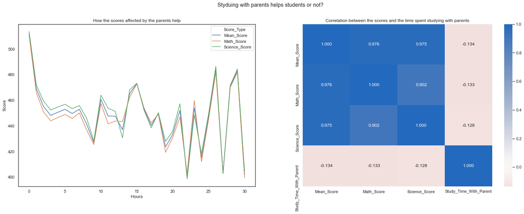

```python
score_df = df.groupby(['Study_Time_With_Parent']).mean().reset_index()[['Study_Time_With_Parent','Mean_Score','Math_Score',
                                                                        'Science_Score']]
data = pd.melt(score_df, id_vars=['Study_Time_With_Parent'],
               value_vars=['Mean_Score','Math_Score', 'Science_Score'],
               var_name="Score_Type", value_name='Score')

fig, ax = plt.subplots(1, 2, figsize=(25, 8))

sb.lineplot(ax=ax[0], data = data, x = 'Study_Time_With_Parent', y='Score', hue='Score_Type');
ax[0].set(title='How the scores affected by the parents help', xlabel='Hours', ylabel='Score')

sb.heatmap(df[['Mean_Score','Math_Score', 'Science_Score', 'Study_Time_With_Parent']].corr(), annot = True, fmt = '.3f',
           cmap = 'vlag_r', center = 0)
ax[1].set(title='Correlation between the scores and the time spent studying with parents')

plt.suptitle("Styduing with parents helps students or not?", y=0.98);
```

- #### From the univariate exploration I reached the conclusion that it's very rare that students spend more than 5 hours sudying with their parent(s).
- #### With that in mind I can see that:
  - #### when considering only number of hours between 0 and 5, there's a significant drop of about 70 points in the score, so studying with parents does not seems to be a factor of success
  - #### As the hours studing with parent grows the performance is not clearly affected, meaning that sometimes the performance affected positively and sometimes negatively (maybe some students have problems with math and science that parents sometimes can solve and sometimes can't due to academic background)
  - #### The heat map in right shows that there is a weak negative correlation between scores and study time with parent.

## Multivariate Exploration

> Since my main goal is to look the consequences that the family structure has in students performance I'll loo further the relation of parents with students taking into account the siblings as well. Here I'll investigate the impact of siblings presence in the cases of single parent families, in the case of parent time with students and in the case of the academic background of parents.

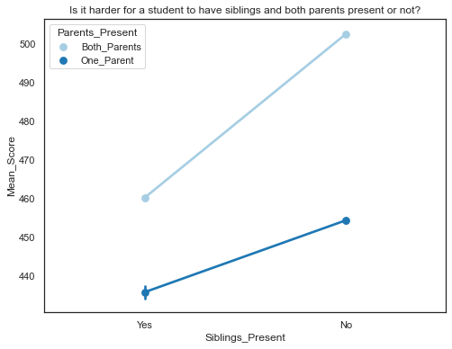

```python
plt.figure(figsize = [8, 6])

ax = sb.pointplot(data = df,
                  x = 'Siblings_Present', y = 'Mean_Score', hue = 'Parents_Present',
                  palette = sb.color_palette("Paired")
                 )
plt.title('Is it harder for a student to have siblings and both parents present or not?', fontsize = 12);
```

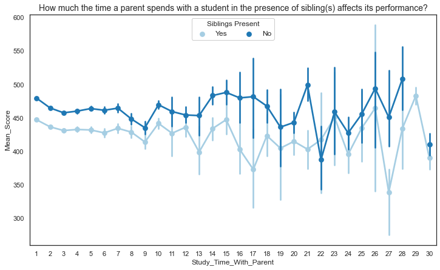

```python
plt.figure(figsize = [12, 7])

ax = sb.pointplot(data = df[df['Study_Time_With_Parent'] > 0],
                  x = 'Study_Time_With_Parent', y = 'Mean_Score', hue = 'Siblings_Present',
                  palette = sb.color_palette('Paired')
                 )
ax.legend(loc = 9, ncol = 6, framealpha = 1, title = 'Siblings Present', fontsize=12)
plt.title('How much the time a parent spends with a student in the presence of sibling(s) affects its performance?', fontsize = 14);
```

- #### I can see that the presence of siblings is not a good factor for students performance even if parents spend significant time with students.

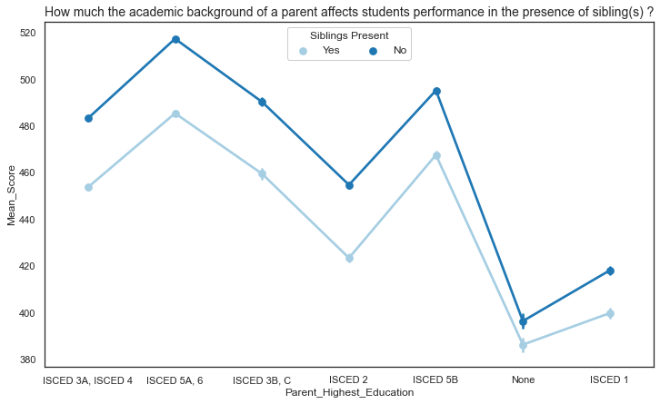

```python
plt.figure(figsize = [12, 7])
ax = sb.pointplot(data = df,
                  x = 'Parent_Highest_Education', y='Mean_Score', hue='Siblings_Present',
                  palette = sb.color_palette("Paired"))
ax.legend(loc = 9, ncol = 6, framealpha = 1, title = 'Siblings Present', fontsize=12)
plt.title('How much the academic background of a parent affects students performance in the presence of sibling(s) ?', fontsize = 14);
```